# Analysis of Glucose Clamp Data

Nathan Qi, Innocence Harvey and Dave Bridges

April 7, 2017

# Data Entry

This analysis uses the averages and errors calculated first by animal, then averaged across groups. The clamp data is the average clamped values.

# Glucose Levels During Clamp

Glucose levels were kept the same between groups throughout the experiment, as expected.

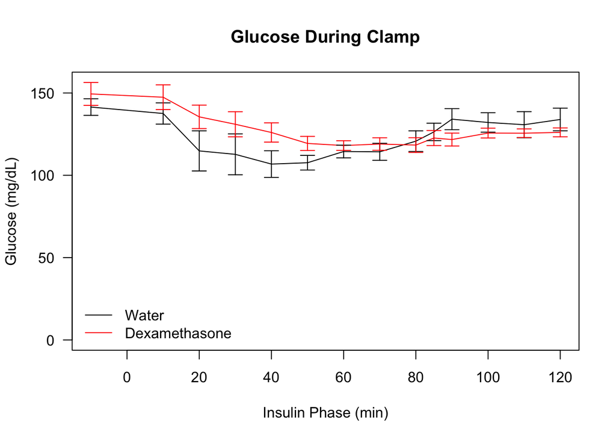

During the clamp, the goal is to keep glucose constant between 120 and 130 mg/dL throughout the experiment. There was a drop in glucose levels shortly after the insulin phase started (time 0). The following is a linear model of Glucose levels vs time, after 80 minutes showing that there was a significant effects of treatment on Glucose levels in this timeframe. The dexamethasone treated group had lower blood glucose during this phase.

Linear model of Glucose levels at the end of the clamp phase

| term | estimate | std.error | statistic | p.value |
| --- | --- | --- | --- | --- |
| (Intercept) | 119.697 | 5.556 | 21.55 | 0.000 |
| Time | 0.116 | 0.054 | 2.15 | 0.069 |
| TreatmentDexamethasone | -7.108 | 1.387 | -5.13 | 0.001 |

# Glucose Infusion Rate

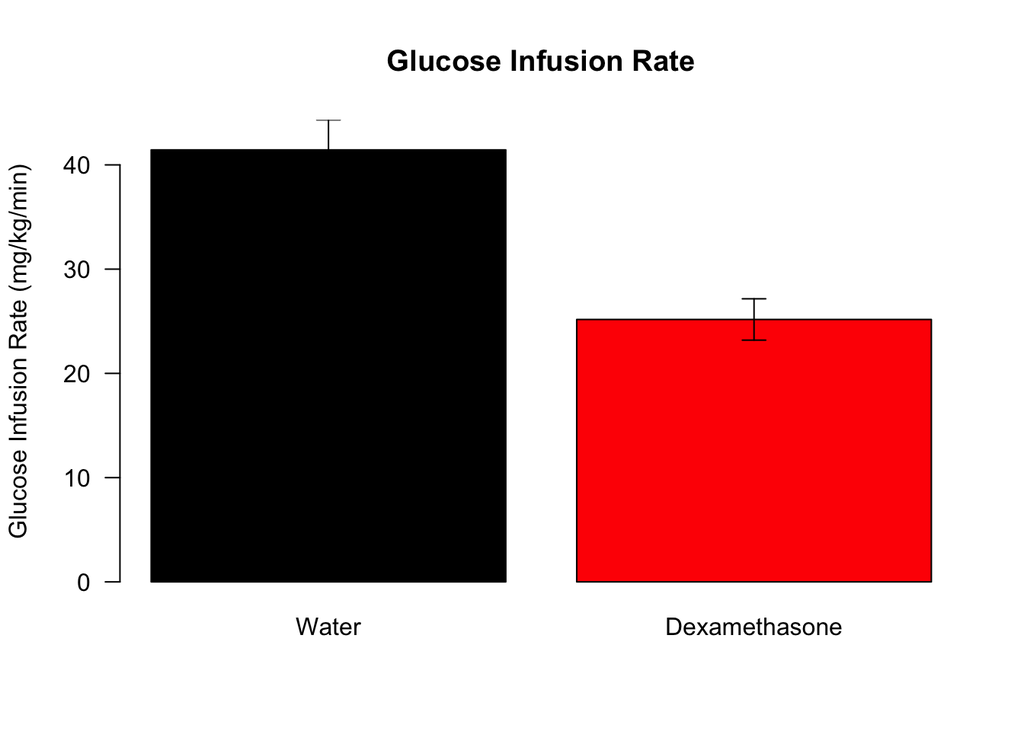

For the dexamethasone group, there was an average of 39.257% reduction in glucose infusion rates.

Shapiro-Wilk Tests for Glucose Infusion Rates

| Treatment | Shapiro |
| --- | --- |
| Water | 0.086 |
| Dexamethasone | 0.447 |

Summary of t-tests for glucose infusion rates

| estimate1 | estimate2 | statistic | p.value | parameter | conf.low | conf.high | method | alternative |
| --- | --- | --- | --- | --- | --- | --- | --- | --- |
| 41.4 | 25.2 | 4.82 | 0 | 25 | 9.32 | 23.2 | Two Sample t-test | two.sided |

Shapiro-Wilk tests showed that the two groups could be presumed to have equal variance, and Levene’s test showed that we can assume equal variance (p=0.736) so Student’s *t*-tests were used to obtain a p-value of **0**.

This is the time course for GIR over the experiment

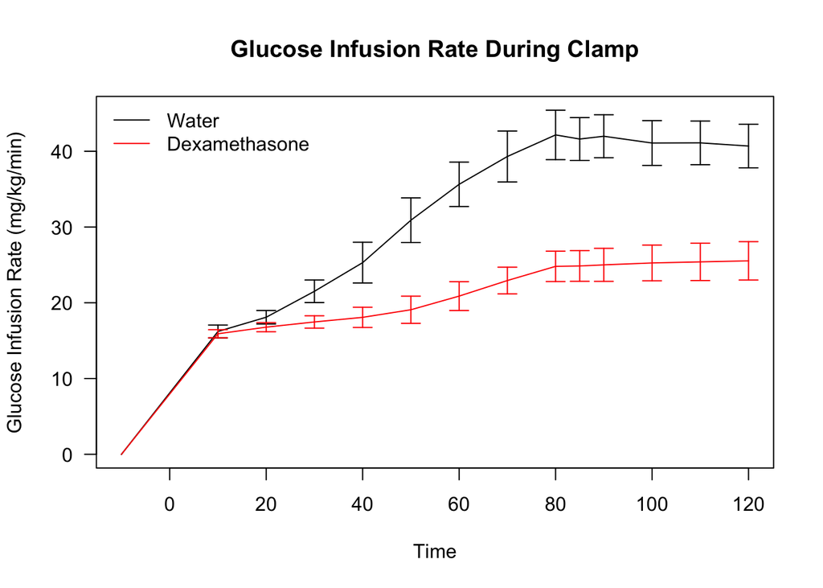

# Hepatic Glucose Production

## Glucose Production in HFD

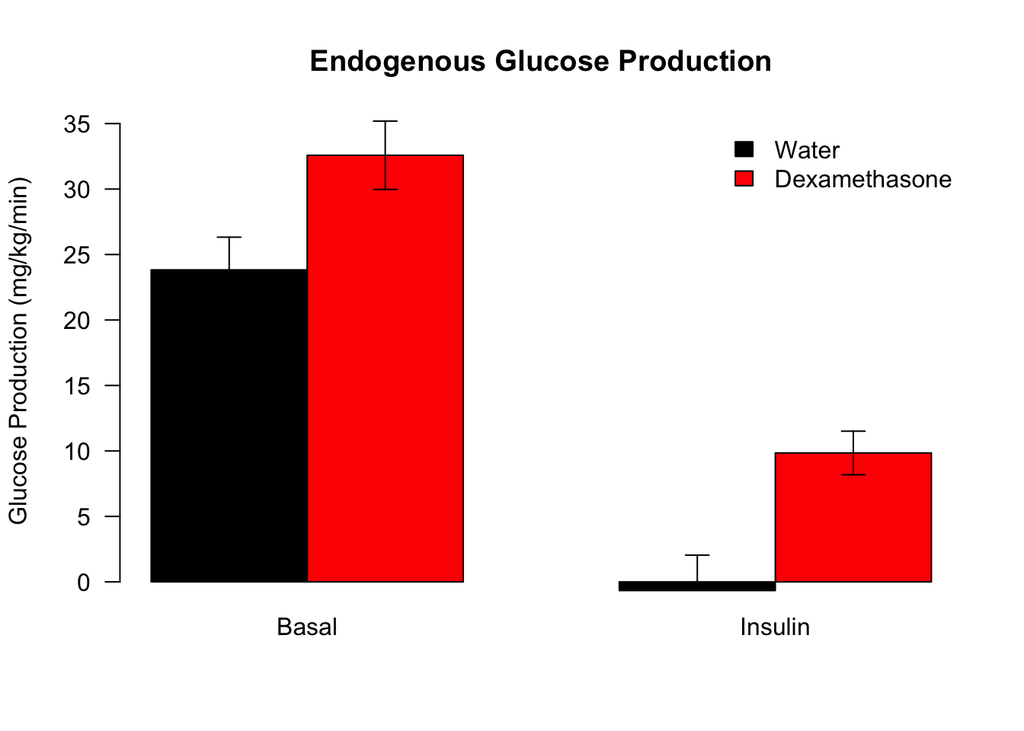

Mean and SD of Hepatic glucose production

| Treatment | Basal | Insulin | Basal1 | Insulin1 |
| --- | --- | --- | --- | --- |
| Water | 23.8 | -0.662 | 2.50 | 2.70 |
| Dexamethasone | 32.6 | 9.846 | 2.61 | 1.66 |

Endogenous glucose production was 36.732 percent higher in the dexamethasone-treated group in the basal condition. Under insulin stimulated conditions, endogenous glucose production was increased from nearly zero to 9.846 mg/kg/min (a -1588.054 fold increase). A Shapiro-Wilk test showed that these groups were normally distributed:

Shapiro-Wilk Tests for Basal HGP

| Treatment | Status | Shapiro |
| --- | --- | --- |
| Water | Basal | 0.306 |
| Water | Insulin | 0.952 |
| Dexamethasone | Basal | 0.686 |
| Dexamethasone | Insulin | 0.323 |

Summary of t-tests for endogenous glucose production

|  | estimate1 | estimate2 | statistic | p.value | parameter | conf.low | conf.high | method | alternative |
| --- | --- | --- | --- | --- | --- | --- | --- | --- | --- |
| Basal | 23.828 | 32.58 | -2.38 | 0.026 | 23 | -16.4 | -1.13 | Two Sample t-test | two.sided |
| Insulin | -0.662 | 9.85 | -3.50 | 0.002 | 25 | -16.7 | -4.33 | Two Sample t-test | two.sided |

A Levene’s test showed that both Basal (p=0.441) and Insulin phase EGP (p=0.276) can be presumed to have equal variance. Therefore a Student’s *t*-test was used for both comparasons.

## Suppression of Hepatic Glucose Output

Percent reductions in glucose output relative to basal were calculated for each mouse using the averaged HGP values >80 minutes

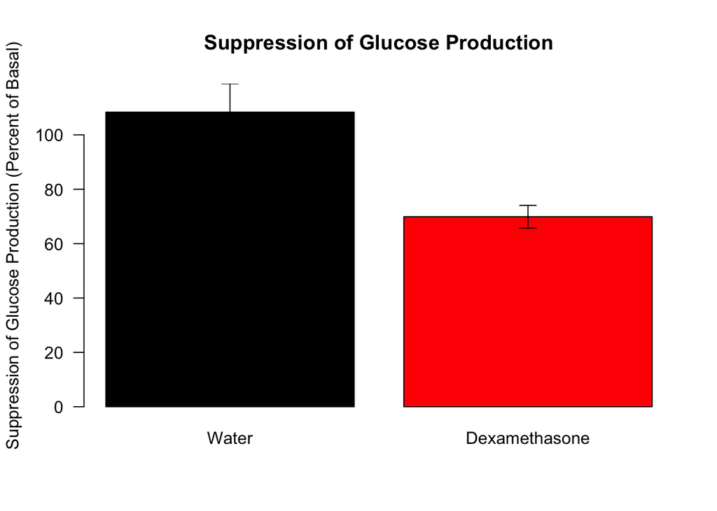

For the water group, there was an average of 108.369% reduction in glucose production, but this was only 69.905% reduction in the dexamethasone treated group.

Shapiro-Wilk Tests for Suppression of HGP

| Treatment | Shapiro |
| --- | --- |
| Water | 0.832 |
| Dexamethasone | 0.975 |

Summary of t-tests for suppression of endogenous glucose production

| estimate1 | estimate2 | statistic | p.value | parameter | conf.low | conf.high | method | alternative |
| --- | --- | --- | --- | --- | --- | --- | --- | --- |
| 108 | 69.9 | 3.87 | 0.001 | 25 | 18 | 58.9 | Two Sample t-test | two.sided |

# Glucose Turnover

This is calculated by the rate of tracer infusion divided by the specific activity of the tracer. It should increase with insulin and represents the glucose that is taken up by the body. At the basal level this is equal to the HGP since the GIR is zero.

Glucose turnover is significantly higher in HFD dex vs. controls (p=0.0262) during the basal period (not in the presence of insulin); however, this difference goes away during the clamp.

## Glucose Turnover on HFD

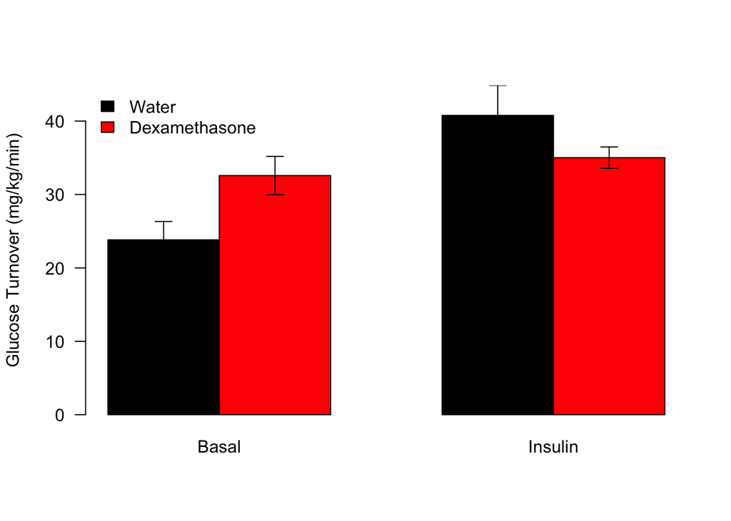

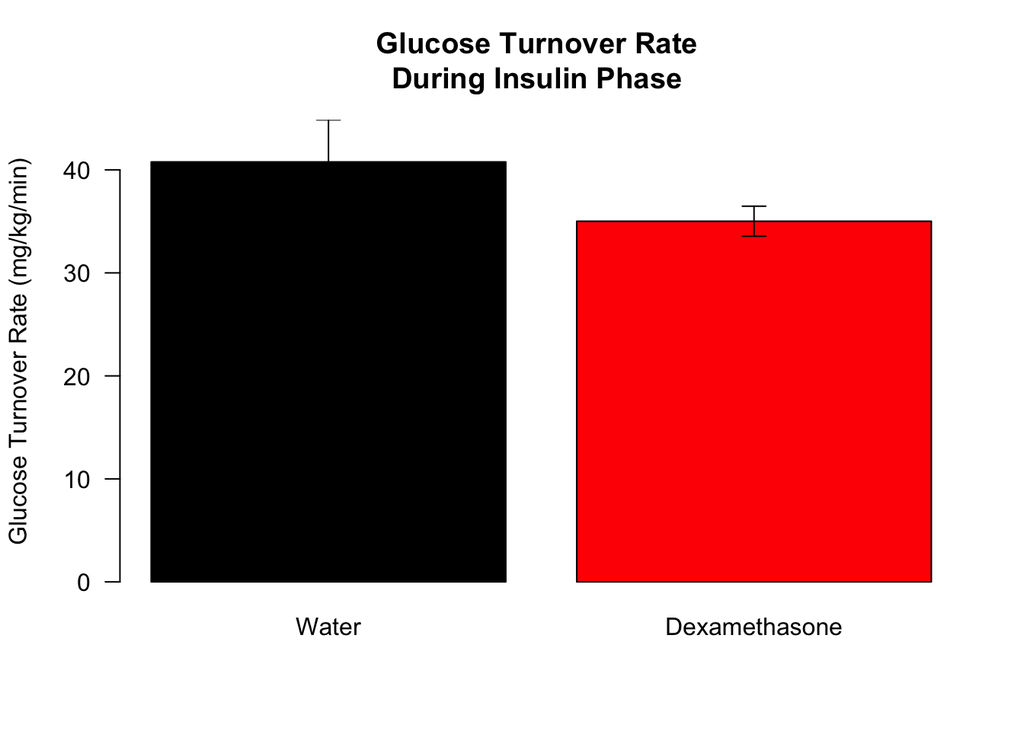

For the dexamethasone group, there was a 14.126% reduction in glucose turnover during the insulin phase.

Shapiro-Wilk Tests for glucose turnover during the insulin phase

| Treatment | Shapiro |
| --- | --- |
| Water | 0.536 |
| Dexamethasone | 0.501 |

Summary of t-tests for glucose turnover during the insulin phase

| estimate1 | estimate2 | statistic | p.value | parameter | conf.low | conf.high | method | alternative |
| --- | --- | --- | --- | --- | --- | --- | --- | --- |
| 40.8 | 35 | 1.52 | 0.141 | 25 | -2.05 | 13.6 | Two Sample t-test | two.sided |

# Insulin and Glucose Levels During the Clamp

## Insulin levels

Insulin levels were significantly higher in the basal period in the dex-treated mice (p=0.0001) there was no difference between the groups during the clamp.

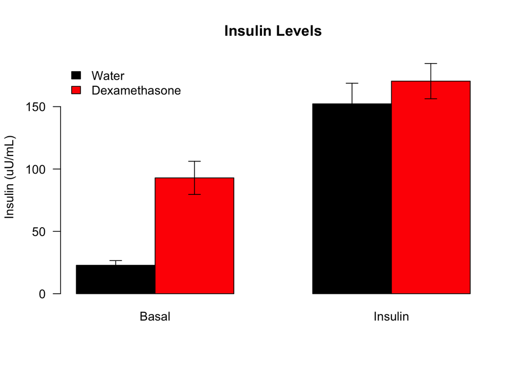

## Insulin Clearance Rates

There was no difference in insulin clearance between the groups

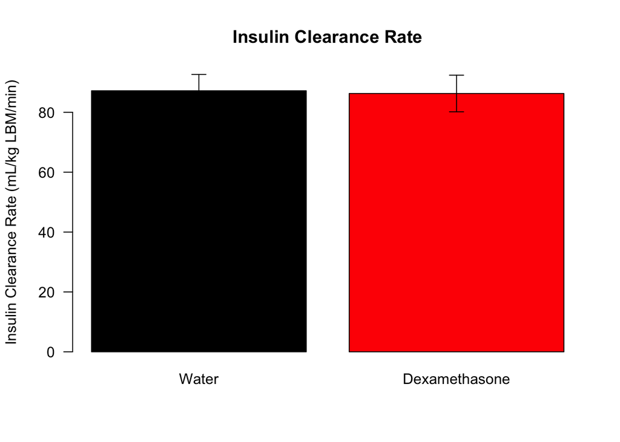

Shapiro-Wilk Tests for insulin clearance rates

| Treatment | Shapiro |
| --- | --- |
| Water | 0.226 |
| Dexamethasone | 0.990 |

Summary of t-tests for insulin clearance rates

| estimate1 | estimate2 | statistic | p.value | parameter | conf.low | conf.high | method | alternative |
| --- | --- | --- | --- | --- | --- | --- | --- | --- |
| 87.2 | 86.3 | 0.108 | 0.915 | 23 | -16.5 | 18.3 | Two Sample t-test | two.sided |

Shapiro-Wilk tests showed that the two groups could be presumed to have equal variance, and Levene’s test showed that we can assume equal variance (p=0.268) so Student’s *t*-tests were used to obtain a p-value of **0.915**.

## Glucose Levels

Glucose was kept similar between the groups throughout the experiment

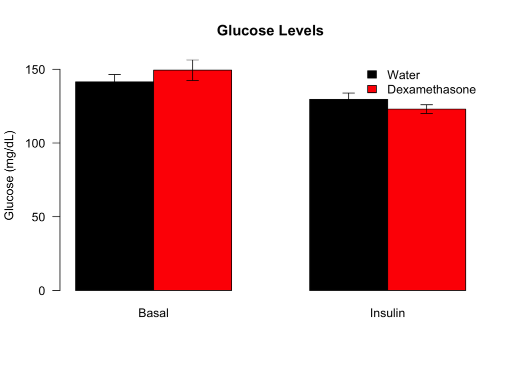

# 2-Deoxyglucose Uptake in Tissues

# Glucose Disposal Metabolism

## Glycolysis

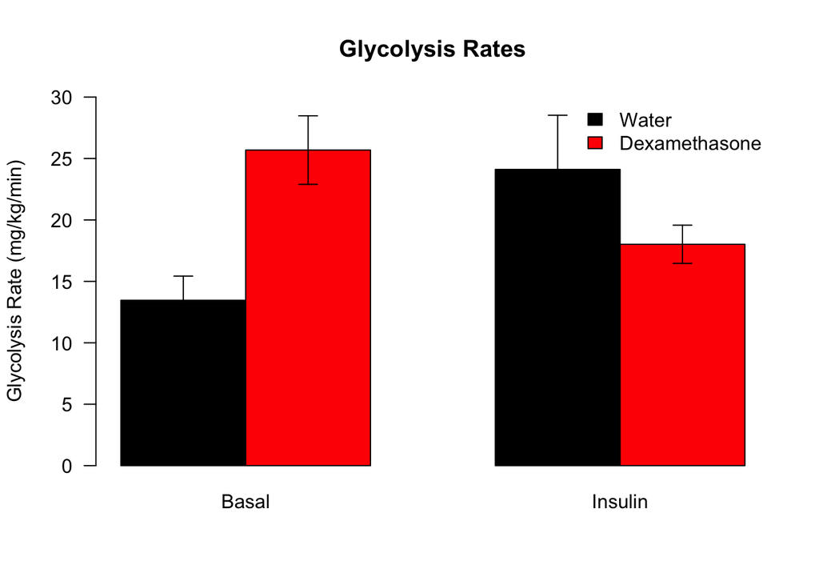

## Glycogen Synthesis Rate

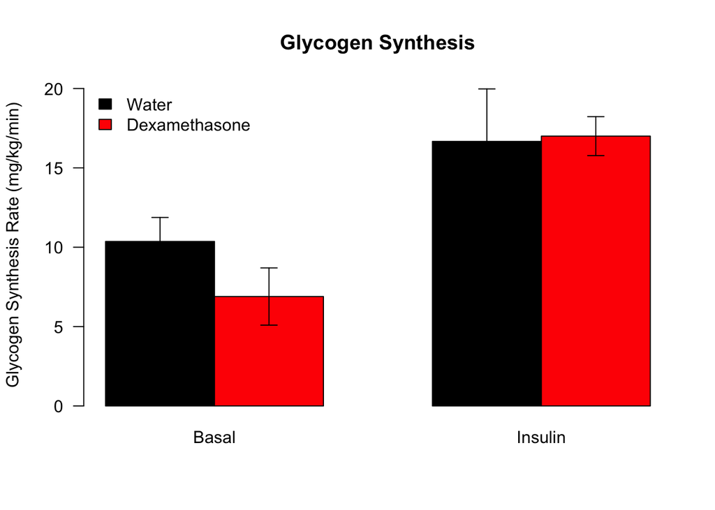

# Time Course Data

## Glucose over time

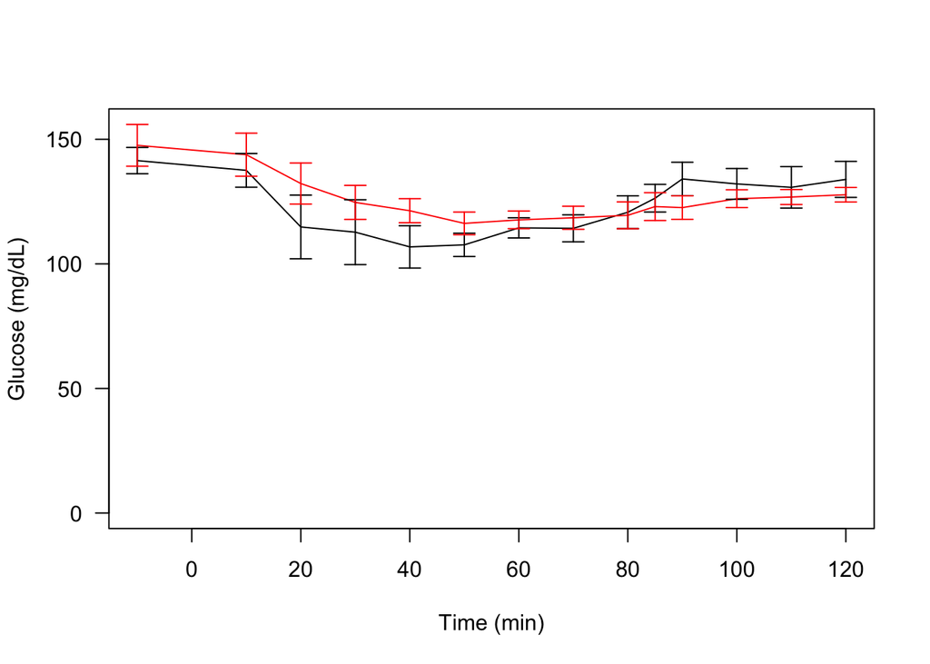

The time course data can be found in ../../data/raw/Glucose Clamp Timecourse Data.csv.